# Day 1 Homework With Answers

# 1 Learning Objectives

- Formulate a data model of a new subject area from scratch

# 2 Introduction

We are going to take an example of an Indian Carry Out menu and create a data model over the next two nights!

Again you have the choice of using Navicat, Visual Paradigm online, or paper and pencil.

If using Visual Paradigm try using the template for Entity Relationship Diagram https://diagrams.visual-paradigm.com/#proj=0&type=ERDiagram

# 3 Requirement description

The owners of the restaurant want to reduce the time it takes to take over the counter orders at busy times by providing customers with an in-store iPad app that allows them to create their order when they arrive. The app should :

1. Allow customers to browse the menu by different menu categories :
- Main menu categories e.g. Appetisers, Mains, Vegetarian Sides, Breads, Rice, Sundries
- Owner Categories e.g Chefs Specials; Western Dishes; Traditional Dishes
- Lifestyle Choice Categories, e.g. Vegan, Vegetarian
2. A menu item may be in more than one category and under each category the customer will see a list of menu items.
3. Each menu item has a number, a name, description, price and list of main ingredients
4. In addition a menu item may be classified by one or more allergen types eg. Nut, Gluten, Dairy
5. The app will enable customers to select items and create their order as they browse;
6. The app will allow customer to enter their name as a reference for the order and to enter their loyalty card number if they have one;
7. The app will be feeding into a central system. By logging in the owners will be able to view all the orders that have been entered and review which have been completed, which are in progress and which are in the queue;
8. The order data collected will also allow the owner to analyse numbers of orders on days and how long orders took to process.

The app only needs to allow customers to view/browse the menu, create an order, identify themselves and submit an order. The owners do not want the app to take payments at this time.

# 4 MVP Task

Create an LDM for the Menu Item subject area covering the requirements listed in 1 - 4 above:

- Entities
- Attributes
- Relationships (resolving many to many relationships where required)
- Primary and Foreign keys

Identify Classification or Category entities with a different colour coding.

# 5 Extension task

The managers decide they would also like some information about the Balti Curries restaurant available on the app for mobile use.

This will cover anything the customer might need to know if they are using the app remotely and would like to place an order over the phone to pick up later from the restaurant.

Information to be available on the app will be:

- Restaurant phone number
- Location
- Opening hours

Identify any additional entities and relationships (complete attributes tomorrow) into another subject area - Restaurant Information

# 6 Solutions

## 6.1 MVP task

**Menu Item Subject Area**

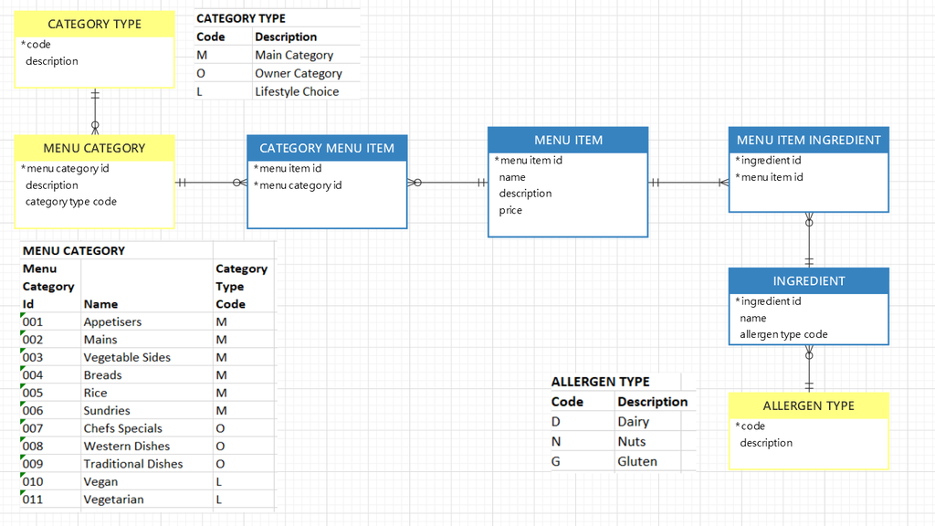

## 6.2 Extension task

**Restaurant Info Subject Area**

(Note: keys included in solution diagram as required in the Navicat tool to create relationships)

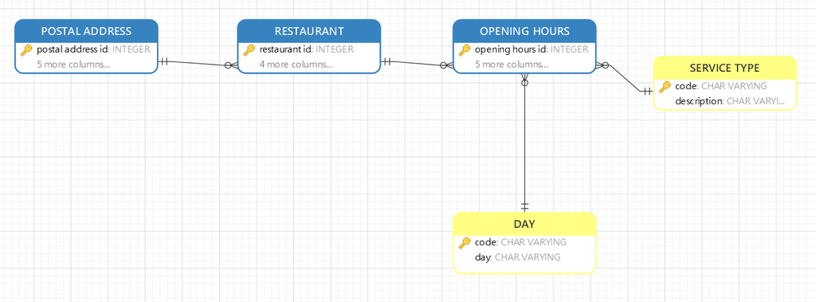